# Coursera PracMachLearn course project (JHU Data Science for R)

Scot J Matkovich

October 3, 2021

## Introduction (Course Project instructions)

Using devices such as Jawbone Up, Nike FuelBand, and Fitbit it is now possible to collect a large amount of data about personal activity relatively inexpensively. These type of devices are part of the quantified self movement – a group of enthusiasts who take measurements about themselves regularly to improve their health, to find patterns in their behavior, or because they are tech geeks. One thing that people regularly do is quantify how much of a particular activity they do, but they rarely quantify how well they do it. In this project, your goal will be to use data from accelerometers on the belt, forearm, arm, and dumbell of 6 participants. They were asked to perform barbell lifts correctly and incorrectly in 5 different ways. More information is available from the website [here](http://groupware.les.inf.puc-rio.br/har) (see the section on the Weight Lifting Exercise Dataset).

The goal of your project is to predict the manner in which they did the exercise. This is the “classe” variable in the training set. You may use any of the other variables to predict with. You should create a report describing how you built your model, how you used cross validation, what you think the expected out of sample error is, and why you made the choices you did. You will also use your prediction model to predict 20 different test cases.

### Libraries used

```r
require(downloader)
require(e1071)
require(caret)
require(corrplot)
require(rpart)
require(rattle)
require(parallel) # for Windows parallel processing
require(doParallel) # for Windows parallel processing
```

### Data download and import

```r
trainSite <-"https://d396qusza40orc.cloudfront.net/predmachlearn/pml-training.csv"
testSite <- "https://d396qusza40orc.cloudfront.net/predmachlearn/pml-testing.csv"
train_csv <- "./data/pml-training.csv"
test_csv <- "./data/pml-testing.csv"

if (!file.exists("./data")) {
  dir.create("./data")
  }
if (!file.exists(train_csv)) {
  download(trainSite, destfile=train_csv)
  }
if (!file.exists(test_csv)) {
  download(testSite, destfile=test_csv)
}

trainInput <- read.csv(train_csv, header=T, row.names=1)
testInput <- read.csv(test_csv, header=T, row.names=1)

# remove non-numeric descriptor columns but preserve classe (outcome) column

trainData <- trainInput[, sapply(trainInput, is.numeric)]
testData <- testInput[, sapply(testInput, is.numeric)]
trainData$classe <- trainInput$classe
testData$classe <- testInput$classe
```

For this exercise, columns with any missing values (NA) will be removed from training and test sets rather than using an imputation function.

```r
train.na <- apply(is.na(trainData), 2, sum)
train.cols.na <- which(train.na != 0)

test.na <- apply(is.na(testData), 2, sum)
test.cols.na <- which(test.na != 0)

if (length(train.cols.na) != 0) {
  trainData.na.removed <- trainData[,-train.cols.na]
} else {
  trainData.na.removed <- trainData
}
if (length(test.cols.na) != 0) {
  testData.na.removed <- testData[,-test.cols.na]
} else {
  testData.na.removed <- testData
}

# remove columns including 'timestamp' or 'window' names
colRemove.train <- grepl("^X|timestamp|window", names(trainData.na.removed))
trainCleaned <- trainData.na.removed[, !colRemove.train]
colRemove.test <- grepl("^X|timestamp|window", names(testData.na.removed))
testCleaned <- testData.na.removed[, !colRemove.test]
```

Comparison of column (variable) names in cleaned training and test sets:

```r
if (ncol(trainCleaned) == ncol(testCleaned)) {
  print("Training and test sets have same numbers of columns")
  samecol <- names(trainCleaned) != names(testCleaned)
  if (sum(samecol) != 0) {
  print("Training and test sets do not have same column names")
  print(paste("Different names for column",which(samecol != 0)))
  print(colnames(trainCleaned)[which(samecol != 0)])
  print(colnames(testCleaned)[which(samecol != 0)])
  }
} else {
  print("Training and test sets have different numbers of columns")
}
```

```
## [1] "Training and test sets have same numbers of columns"
## [1] "Training and test sets do not have same column names"
## [1] "Different names for column 53"
## [1] "classe"
## [1] "problem_id"
```

It is expected that the training and test data sets contain the same numeric predictor variables, but that the training set contains the outcome variable “class” while the test data set instead contains the variable “problem_id” for labeling quiz answers.

## Modeling plan

1. model-based prediction to define Bayesian decision boundaries (discriminant analysis methods, naive Bayes)
2. boosting (weighted addition of a group of weak predictors in a decision tree to obtain a stronger final predictor. Multiple decision trees are grown using information from previously grown trees.)
3. random forest (bootstrap aggregation, or ‘bagging’, on classification/regression trees. Multiple decision trees are built from bootstrapped training samples.) Resampling methods other than the bootstrap can be employed, such as n-fold cross-validation.

Of these, random forests have been described as robust to outliers and capable of handling highly correlated predictors. Because random forests force each tree split to use only a random subset of the predictors (when *m*, the number of random predictors, is less than *p*, the total number of predictors), the multiple trees created by the procedure are largely decorrelated (James et al., An Introduction to Statistical Learning 2nd edition, section 8.2.2).

## Exploratory data analysis

The cleaned training data set contains 19622 observations and 53 variables, including the outcome “classe”. The cleaned testing data set contains 20 observations and 52 predictor variables.

Random forest models are described as resistant to outliers, skewed variables and highly correlated variables. Nonetheless, the cleaned training data will be examined for skewness and correlation.

Skewness calculations:

```r
skewValues <- apply(trainCleaned[,-53], 2, skewness)
```

Only a few predictor variables display distributions with |skew| > 25: gyros_dumbbell_x, gyros_dumbbell_y, gyros_dumbbell_z, gyros_forearm_y, gyros_forearm_z

Inter-variable correlation:

```r
trainCleaned.cor <- cor(trainCleaned[-53])
```

Figures are in the Appendix.

## Random forest modeling

To gauge model accuracy (out-of-sample error) the training data set will be split into a new training set and hold-out (validation) set. If accuracy is 99% or over with the chosen tuning parameters, no further model tuning will be performed. Kuhn & Johnson 2013 demonstrate that varying *m<sub>try</sub>* can influence classification sensitivity and specificity (Fig. 14.8, p. 388) and 5 values of *m<sub>try</sub>* will be assessed during model training (tuneLength = 5).

Split the cleaned training data into model training and model validation sets, 70:30 ratio:

```r
set.seed(2273)
inTrain <- createDataPartition(trainCleaned$classe, p=0.70, list=F)
trainModel <- trainCleaned[inTrain, ]
testModel <- trainCleaned[-inTrain, ]
```

Fit model (using parallel processing capabilities on Windows if available):

```r
# train model using parallel processing on >=2 (flexible) cores if available. To use, change header to eval = T

if (detectCores() >= 4) {
  cluster <- makeCluster(detectCores() - 2) # leave 2 cores for OS
  clusterEvalQ(cluster, library(foreach))
  registerDoParallel(cluster)
  fitControl <- trainControl(method="cv", number=10, search="grid", allowParallel=TRUE)
  modelRF.fit <- train(classe ~ ., data=trainModel, method="rf", ntree=1000, tuneLength = 5, trControl=fitControl, do.trace = F)

  stopCluster(cluster)
  registerDoSEQ()
} else {
  fitControl <- trainControl(method="cv", number=10)
  modelRF.fit <- train(classe ~ ., data=trainModel, method="rf", ntree=1000, tuneLength = 5, trControl=fitControl, do.trace = T)
}
```

Trained random forest model description with out-of-bag (OOB) estimate of error rate:

```r
modelRF.fit$finalModel
```

```
##
## Call:
##  randomForest(x = x, y = y, ntree = 1000, mtry = min(param$mtry,      ncol(x)), do.trace = ..2)
##                Type of random forest: classification
##                      Number of trees: 1000
## No. of variables tried at each split: 14
##
##         OOB estimate of  error rate: 0.54%
## Confusion matrix:
##      A    B    C    D    E class.error
## A 3901    4    0    0    1 0.001280082
## B   14 2639    5    0    0 0.007148232
## C    0   17 2374    5    0 0.009181970
## D    0    0   19 2232    1 0.008880995
## E    0    0    2    6 2517 0.003168317
```

See the Appendix for a plot of *m<sub>try</sub>* vs accuracy during cross-validation.

Accuracy on training data:

```r
modelRF.fit$resample
```

```
##     Accuracy     Kappa Resample
## 1  0.9963636 0.9954003   Fold03
## 2  0.9970909 0.9963206   Fold09
## 3  0.9949054 0.9935555   Fold04
## 4  0.9919942 0.9898721   Fold06
## 5  0.9927167 0.9907891   Fold01
## 6  0.9919825 0.9898572   Fold02
## 7  0.9956332 0.9944762   Fold10
## 8  0.9941733 0.9926286   Fold05
## 9  0.9963610 0.9953965   Fold07
## 10 0.9934450 0.9917083   Fold08
```

```r
confusionMatrix.train(modelRF.fit)
```

```
## Cross-Validated (10 fold) Confusion Matrix
##
## (entries are percentual average cell counts across resamples)
##
##           Reference
## Prediction    A    B    C    D    E
##          A 28.4  0.1  0.0  0.0  0.0
##          B  0.0 19.2  0.1  0.0  0.0
##          C  0.0  0.0 17.3  0.2  0.0
##          D  0.0  0.0  0.0 16.2  0.0
##          E  0.0  0.0  0.0  0.0 18.3
##
##  Accuracy (average) : 0.9945
```

Assess model performance against held-out validation data:

```r
predictRF <- predict(modelRF.fit, testModel)
confusionMatrix(as.factor(testModel$classe), predictRF)
```

```
## Confusion Matrix and Statistics
##
##           Reference
## Prediction    A    B    C    D    E
##          A 1672    0    1    0    1
##          B    5 1133    1    0    0
##          C    0    2 1019    5    0
##          D    0    0   10  954    0
##          E    0    0    0    5 1077
##
## Overall Statistics
##
##                Accuracy : 0.9949
##                  95% CI : (0.9927, 0.9966)
##     No Information Rate : 0.285
##     P-Value [Acc > NIR] : < 2.2e-16
##
##                   Kappa : 0.9936
##
##  Mcnemar's Test P-Value : NA
##
## Statistics by Class:
##
##                      Class: A Class: B Class: C Class: D Class: E
## Sensitivity            0.9970   0.9982   0.9884   0.9896   0.9991
## Specificity            0.9995   0.9987   0.9986   0.9980   0.9990
## Pos Pred Value         0.9988   0.9947   0.9932   0.9896   0.9954
## Neg Pred Value         0.9988   0.9996   0.9975   0.9980   0.9998
## Prevalence             0.2850   0.1929   0.1752   0.1638   0.1832
## Detection Rate         0.2841   0.1925   0.1732   0.1621   0.1830
## Detection Prevalence   0.2845   0.1935   0.1743   0.1638   0.1839
## Balanced Accuracy      0.9983   0.9985   0.9935   0.9938   0.9990
```

Model accuracy:

```r
accuracy <- confusionMatrix(as.factor(testModel$classe), predictRF)$overall[1]
```

Thus, the trained model has an accuracy of 0.9949023 with an out-of-sample error of 0.0050977.

## Prediction of test set categories using trained model

The trained model will be used to predict the “classe” variable from the cleaned test data.

```r
testClasse <- predict(modelRF.fit, testCleaned[-53])
testResults <- data.frame(problem_id=testCleaned$problem_id, classe=testClasse)
write.table(testResults, file="course_project_test_predictions.txt", sep="\t")
```

## Appendix: Figures

1. Skewness values of training predictor variables

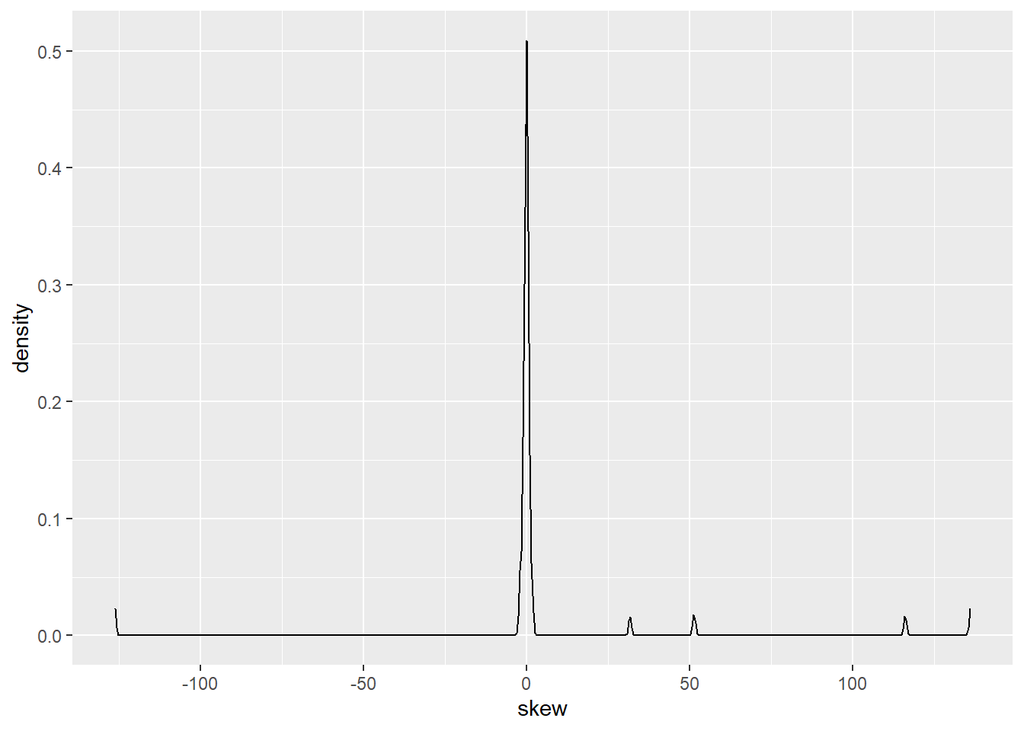

```r
skv <- data.frame(skew=skewValues)
ggplot(skv, aes(x=skew)) + geom_density()
```

2. Correlation plot of training predictor variables

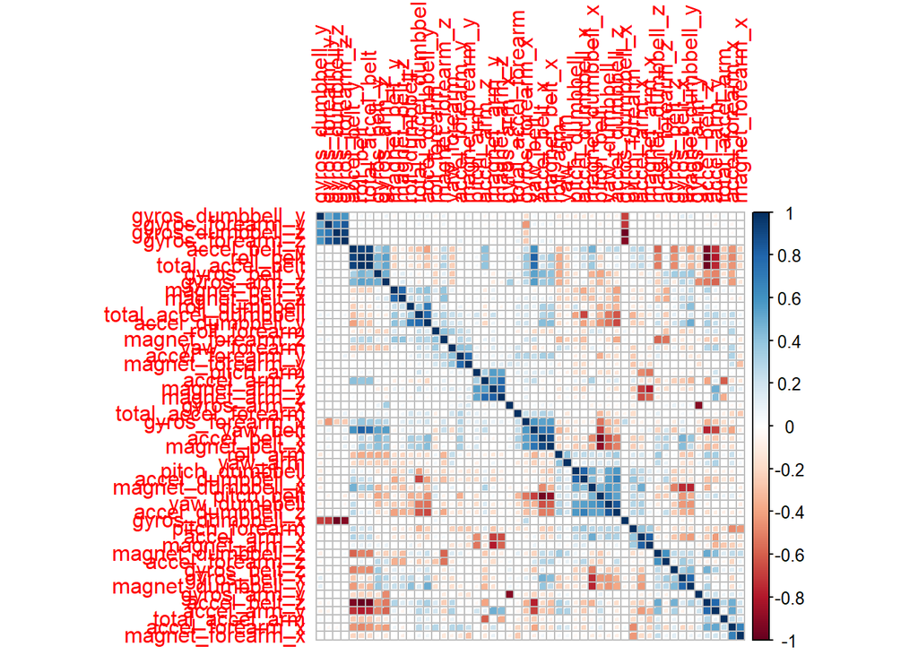

```r
corrplot(trainCleaned.cor, method="square", order="hclust", t1.cex=0.3)
```

3. Example visualization of a decision tree (not necessarily from random forest used in this project)

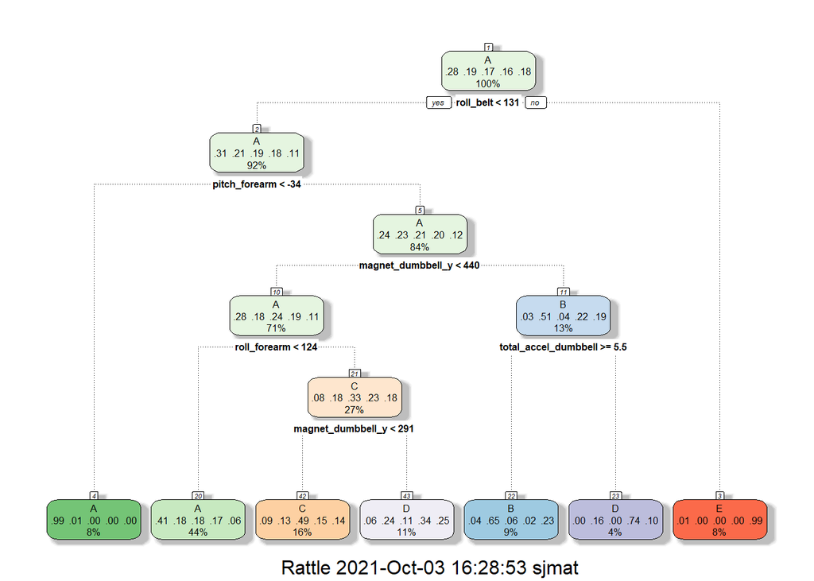

```r
treeModel <- train(classe ~ ., data=trainCleaned, method="rpart", tuneLength=5)
rattle::fancyRpartPlot(treeModel$finalModel)
```

4. Visualization of random forest training for optimal *m<sub>try</sub>*

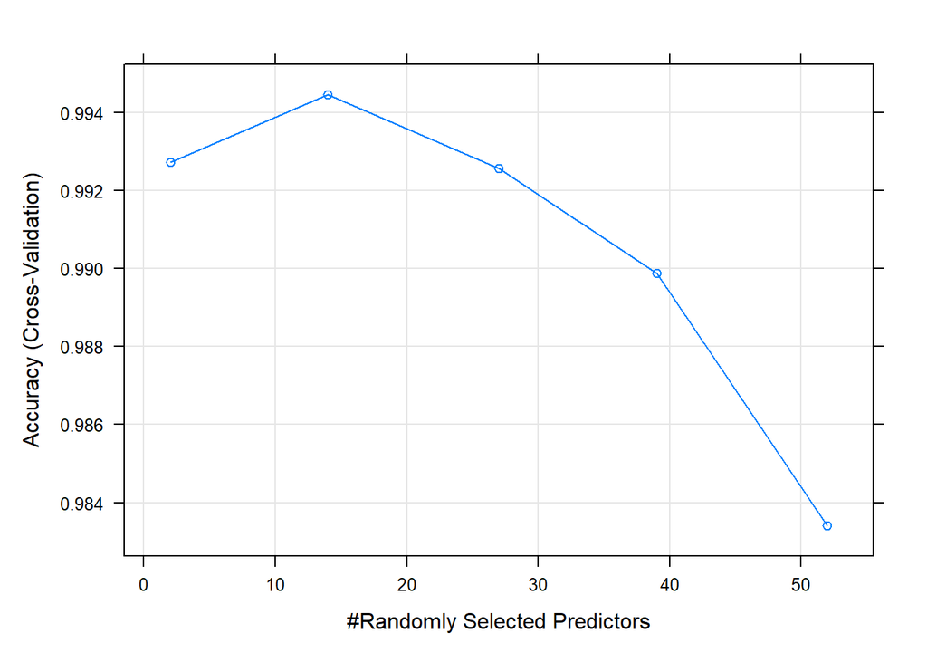

```r
plot(modelRF.fit)
```